# Lab 14 Homework

Claire Fargeix

2021-03-05

## Instructions

Answer the following questions and complete the exercises in RMarkdown. Please embed all of your code and push your final work to your repository. Your final lab report should be organized, clean, and run free from errors. Remember, you must remove the `#` for the included code chunks to run. Be sure to add your name to the author header above. For any included plots, make sure they are clearly labeled. You are free to use any plot type that you feel best communicates the results of your analysis.

Make sure to use the formatting conventions of RMarkdown to make your report neat and clean!

## Load the libraries

```r
library(qtl)
library(qtlcharts)
library(tidyverse)
library(ggmap)
```

**1. We have a satellite collars on a number of different individuals and want to be able to quickly look at all of their recent movements at once. Please load all the data files from `us_individual_collar_data` and use for loop to create plots for all different individuals of the path they move on longitude and latitude.**

```r
data_files <- list.files("data/individual_collar_data", full.names = TRUE)
data_files
```

```
##  [1] "data/individual_collar_data/collar-data-A1-2016-02-26.txt"
##  [2] "data/individual_collar_data/collar-data-B2-2016-02-26.txt"
##  [3] "data/individual_collar_data/collar-data-C3-2016-02-26.txt"
##  [4] "data/individual_collar_data/collar-data-D4-2016-02-26.txt"
##  [5] "data/individual_collar_data/collar-data-E5-2016-02-26.txt"
##  [6] "data/individual_collar_data/collar-data-F6-2016-02-26.txt"
##  [7] "data/individual_collar_data/collar-data-G7-2016-02-26.txt"
##  [8] "data/individual_collar_data/collar-data-H8-2016-02-26.txt"
##  [9] "data/individual_collar_data/collar-data-I9-2016-02-26.txt"
## [10] "data/individual_collar_data/collar-data-J10-2016-02-26.txt"
```

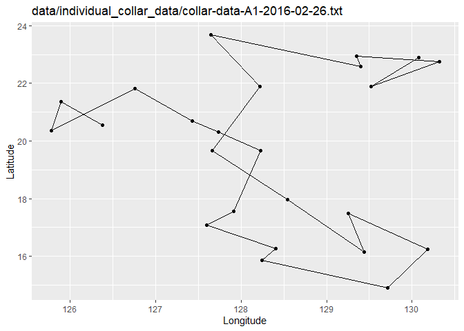

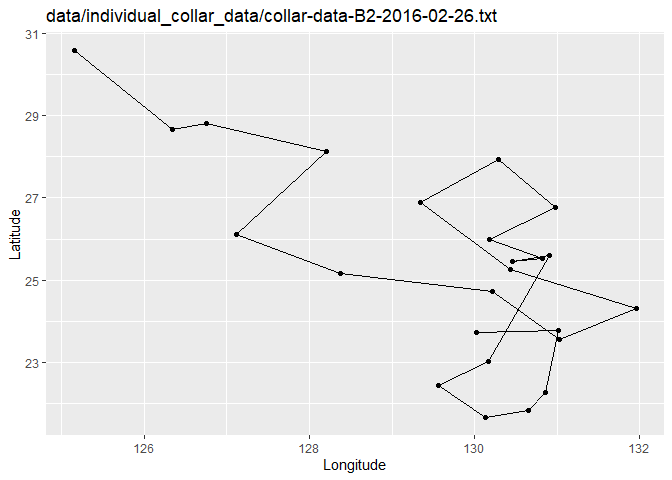

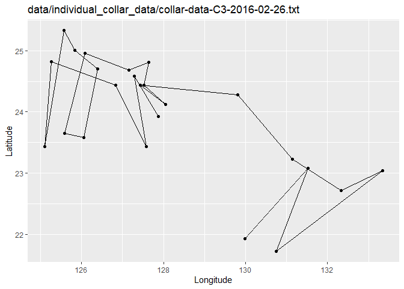

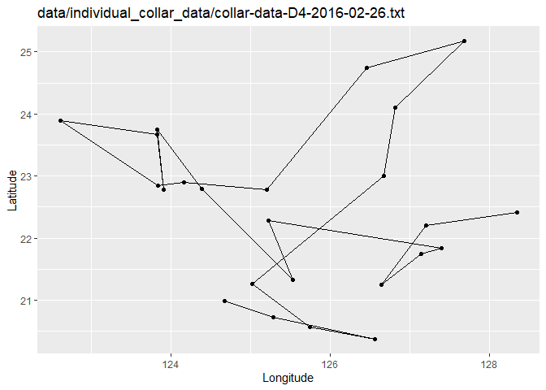

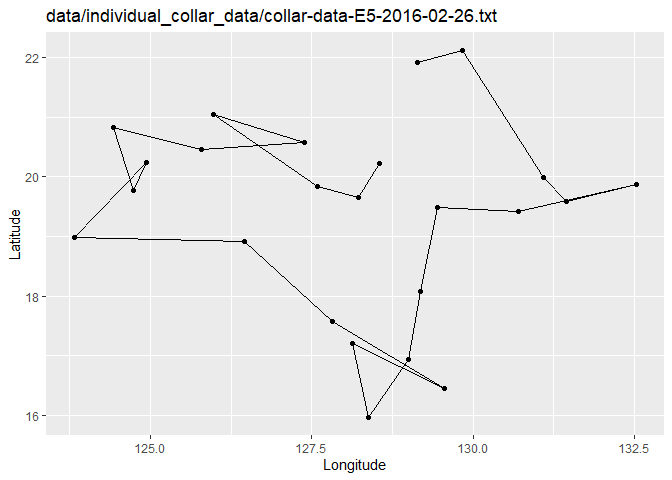

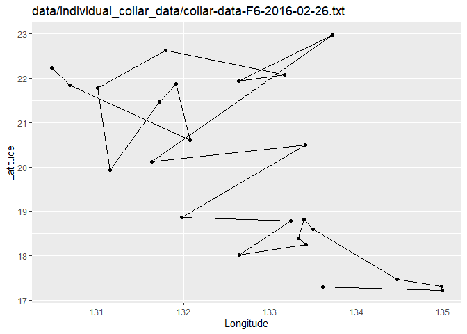

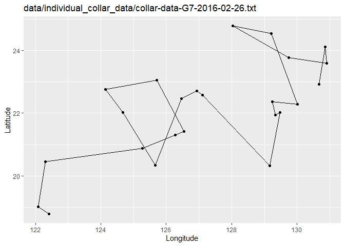

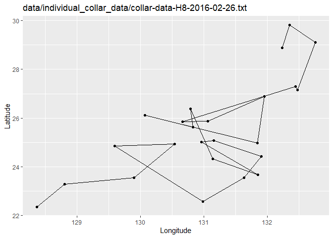

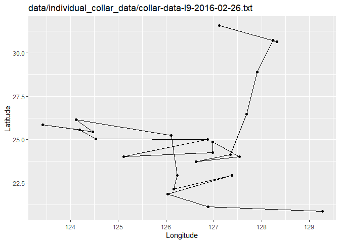

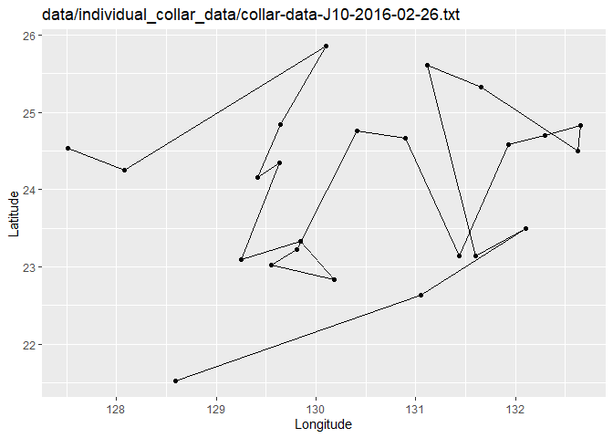

```r
for (i in 1:length(data_files)) {
  data <- as.data.frame(read_csv(data_files[i]))
   print(
    ggplot(data, aes(x=long,y=lat))+
      geom_path()+
      geom_point()+
      labs(title = data_files[i], x = "Longitude", y = "Latitude")
   )
}
```

**2. Please load all the data files from `us_individual_collar_data` and combine all data into one data frame. Create a summary to show what is the maximum and minimum of recorded data points on longitude and latitude.**

```r
totals <- as.data.frame(read_csv(data_files[1]))
totals
```

```
##    X1       date collar                time      lat     long
## 1   1 2016-02-26     A1 2016-02-26 00:00:00 22.89906 130.0816
## 2   2 2016-02-26     A1 2016-02-26 01:00:00 21.88522 129.5197
## 3   3 2016-02-26     A1 2016-02-26 02:00:00 22.74822 130.3214
## 4   4 2016-02-26     A1 2016-02-26 03:00:00 22.94956 129.3474
## 5   5 2016-02-26     A1 2016-02-26 04:00:00 22.58297 129.3996
## 6   6 2016-02-26     A1 2016-02-26 05:00:00 23.67377 127.6464
## 7   7 2016-02-26     A1 2016-02-26 06:00:00 21.88349 128.2205
## 8   8 2016-02-26     A1 2016-02-26 07:00:00 19.67625 127.6657
## 9   9 2016-02-26     A1 2016-02-26 08:00:00 17.97937 128.5463
## 10 10 2016-02-26     A1 2016-02-26 09:00:00 16.14744 129.4414
## 11 11 2016-02-26     A1 2016-02-26 10:00:00 17.47812 129.2572
## 12 12 2016-02-26     A1 2016-02-26 11:00:00 16.23443 130.1813
## 13 13 2016-02-26     A1 2016-02-26 12:00:00 14.91539 129.7140
## 14 14 2016-02-26     A1 2016-02-26 13:00:00 15.85187 128.2453
## 15 15 2016-02-26     A1 2016-02-26 14:00:00 16.27768 128.4020
## 16 16 2016-02-26     A1 2016-02-26 15:00:00 17.09323 127.5978
## 17 17 2016-02-26     A1 2016-02-26 16:00:00 17.55547 127.9155
## 18 18 2016-02-26     A1 2016-02-26 17:00:00 19.67023 128.2321
## 19 19 2016-02-26     A1 2016-02-26 18:00:00 20.32333 127.7343
## 20 20 2016-02-26     A1 2016-02-26 19:00:00 20.68632 127.4315
## 21 21 2016-02-26     A1 2016-02-26 20:00:00 21.81709 126.7546
## 22 22 2016-02-26     A1 2016-02-26 21:00:00 20.36509 125.7810
## 23 23 2016-02-26     A1 2016-02-26 22:00:00 21.35558 125.8911
## 24 24 2016-02-26     A1 2016-02-26 23:00:00 20.54575 126.3804
```

```r
for (i in 1:length(data_files)) {
  data <- as.data.frame(read_csv(data_files[i]))
  totals <- full_join(data, totals)
}
totals
```

```
##     X1       date collar                time      lat     long
## 1    1 2016-02-26    J10 2016-02-26 00:00:00 21.52579 128.5925
## 2    2 2016-02-26    J10 2016-02-26 01:00:00 22.62961 131.0515
## 3    3 2016-02-26    J10 2016-02-26 02:00:00 23.49390 132.1083
## 4    4 2016-02-26    J10 2016-02-26 03:00:00 23.14132 131.6047
## 5    5 2016-02-26    J10 2016-02-26 04:00:00 25.61192 131.1125
## 6    6 2016-02-26    J10 2016-02-26 05:00:00 25.32754 131.6611
## 7    7 2016-02-26    J10 2016-02-26 06:00:00 24.49995 132.6237
## 8    8 2016-02-26    J10 2016-02-26 07:00:00 24.82942 132.6549
## 9    9 2016-02-26    J10 2016-02-26 08:00:00 24.69935 132.3012
## 10  10 2016-02-26    J10 2016-02-26 09:00:00 24.58599 131.9326
## 11  11 2016-02-26    J10 2016-02-26 10:00:00 23.14249 131.4333
## 12  12 2016-02-26    J10 2016-02-26 11:00:00 24.66347 130.8938
## 13  13 2016-02-26    J10 2016-02-26 12:00:00 24.75790 130.4097
## 14  14 2016-02-26    J10 2016-02-26 13:00:00 23.22727 129.8124
```

[output cut: 226 more lines]

```r
summary(totals)
```

```
##        X1             date               collar
##  Min.   : 1.00   Min.   :2016-02-26   Length:240
##  1st Qu.: 6.75   1st Qu.:2016-02-26   Class :character
##  Median :12.50   Median :2016-02-26   Mode  :character
##  Mean   :12.50   Mean   :2016-02-26
##  3rd Qu.:18.25   3rd Qu.:2016-02-26
##  Max.   :24.00   Max.   :2016-02-26
##       time                          lat             long
##  Min.   :2016-02-26 00:00:00   Min.   :14.92   Min.   :122.1
##  1st Qu.:2016-02-26 05:45:00   1st Qu.:20.88   1st Qu.:126.7
##  Median :2016-02-26 11:30:00   Median :22.92   Median :129.1
##  Mean   :2016-02-26 11:30:00   Mean   :22.75   Mean   :128.8
##  3rd Qu.:2016-02-26 17:15:00   3rd Qu.:24.69   3rd Qu.:130.9
##  Max.   :2016-02-26 23:00:00   Max.   :31.57   Max.   :135.0
```

**3. Use the range of the latitude and longitude from Q2 to build an appropriate bounding box for your map and load a map from `stamen` in a terrain style projection and display the map. Then, build a final map that overlays the recorded path from Q1.**

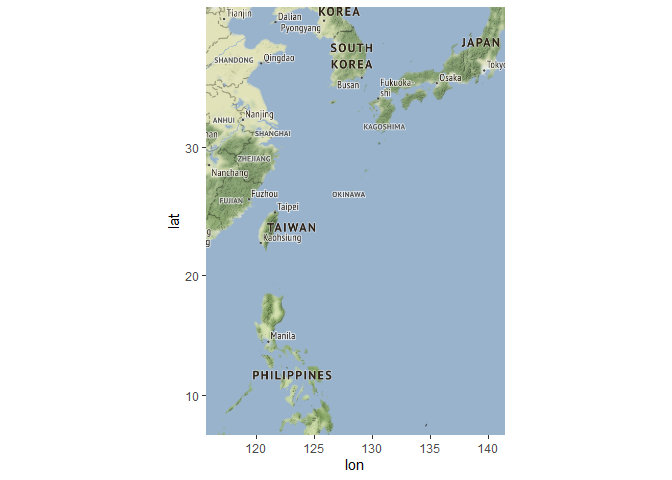

```r
lat <- c(14.92, 31.57)
long <- c(122.1, 135.0)
bbox <- make_bbox(long, lat, f = 0.5)
map <- get_map(bbox, maptype = "terrain", source = "stamen")
ggmap(map)
```

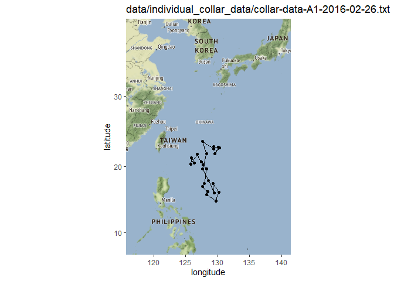

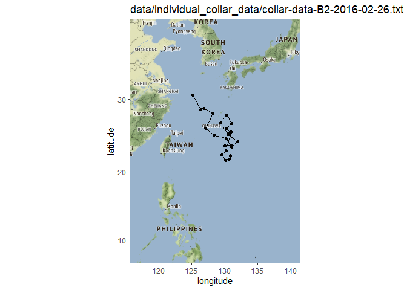

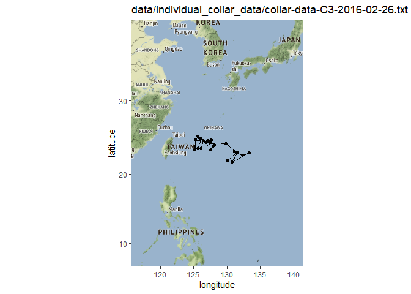

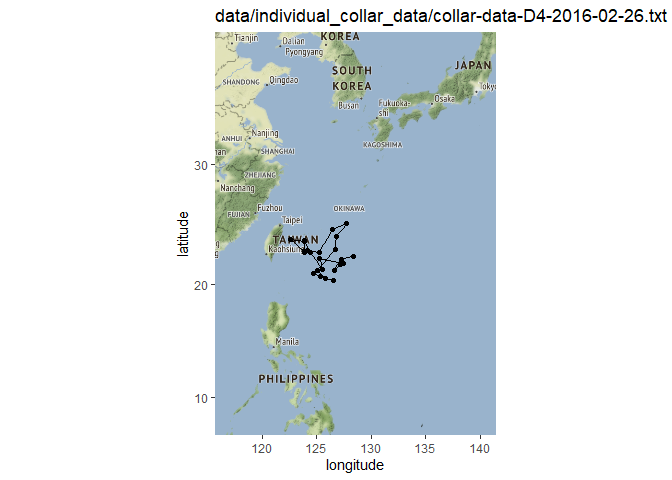

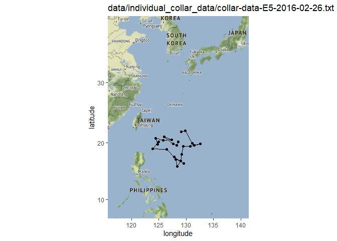

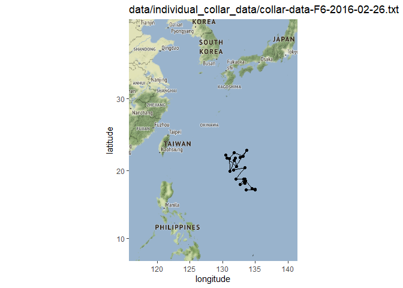

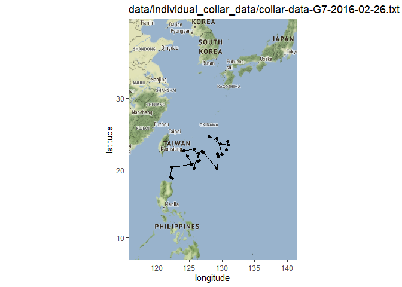

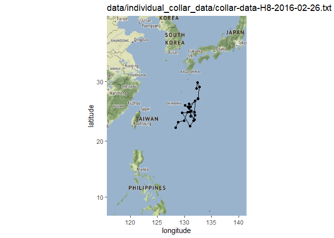

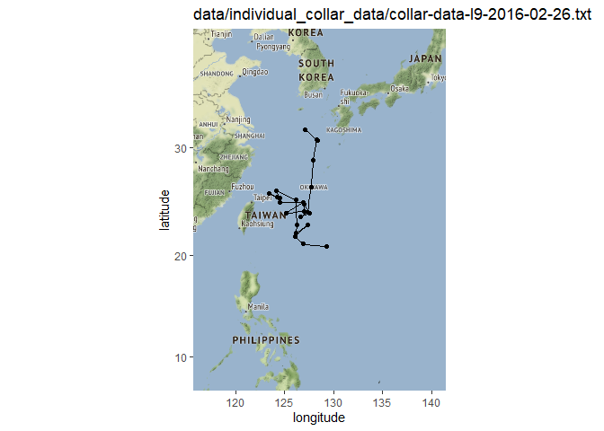

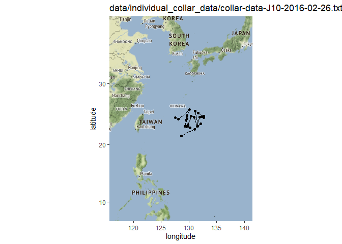

```r
for (i in 1:length(data_files)){
  data_map <- as.data.frame(read_csv(data_files[i]))
  print(
    ggmap(map)+
      geom_path(data = data_map, aes(long,lat))+
      geom_point(data = data_map, aes(long,lat))+
      labs(title = data_files[i], x = "longitude", y = "latitude")
  )
}
```

## Load the Data

We will use the data from an experiment on hypertension in the mouse [Sugiyama et al., Genomics 71:70-77, 2001](https://www.sciencedirect.com/science/article/pii/S0888754300964012?via%3Dihub)

```r
#?hyper
data(hyper)
```

**4. Create a summary of the hypertension data. How many individuals and phenotypes are included in this data set? How many gene markers and chromosomes are included in this data set? Please create a table to show the number of markers on each chromosome.**

```r
summary(hyper)
```

```
##     Backcross
##
##     No. individuals:    250
##
##     No. phenotypes:     2
##     Percent phenotyped: 100 100
##
##     No. chromosomes:    20
##         Autosomes:      1 2 3 4 5 6 7 8 9 10 11 12 13 14 15 16 17 18 19
##         X chr:          X
##
##     Total markers:      174
##     No. markers:        22 8 6 20 14 11 7 6 5 5 14 5 5 5 11 6 12 4 4 4
##     Percent genotyped:  47.7
##     Genotypes (%):
##           Autosomes:    BB:50.1  BA:49.9
##        X chromosome:    BY:53.0  AY:47.0
```

```r
nmar(hyper)
```

```
##  1  2  3  4  5  6  7  8  9 10 11 12 13 14 15 16 17 18 19  X
## 22  8  6 20 14 11  7  6  5  5 14  5  5  5 11  6 12  4  4  4
```

**5. Please make an interactive genetic map of markers for the hypertension data.**

```r
iplotMap(hyper)
```

```
## Set screen size to height=700 x width=1000
```

[interactive chart not shown]

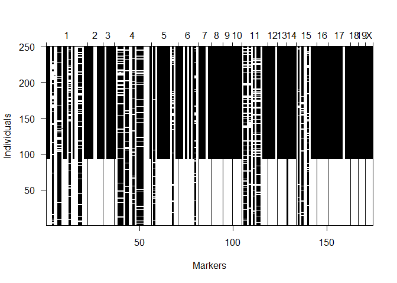

```r
plotMissing(hyper, main="")
```

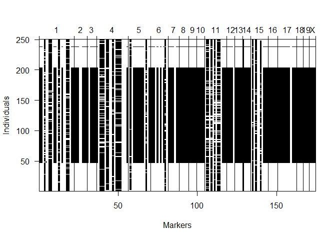

```r
plotMissing(hyper, main="", reorder=1)
```

**7. Based on your answer from previous question, you probably noticed that there are gene markers without data. Please use the function `drop.nullmarkers` to remove markers that have no genotype data. After this, make a new summary to show the number of markers on each chromosome. How many gene markers were dropped? Where were the dropped markers located? Please use the data without nullmarkers for the following questions.**  
One marker from chromosome 14 was dropped.

```r
hyper2 <- drop.nullmarkers(hyper)
```

```r
nmar(hyper2)
```

```
##  1  2  3  4  5  6  7  8  9 10 11 12 13 14 15 16 17 18 19  X
## 22  8  6 20 14 11  7  6  5  5 14  5  5  4 11  6 12  4  4  4
```

**8. Please conduct single-QTL analysis and create a table to give the maximum LOD score on each chromosome based on their blood pressure phenotypes. Which gene marker has the highest LOD score? Which chromosome contains the gene marker that has the highest LOD score? Then, creates an interactive chart with LOD curves from a genome scan for all chromosomes.**  
The highest LOD score is D4Mit164 on chromosome 4.

```r
hyper <- calc.genoprob(hyper, step=1)
hyper_lods <- scanone(hyper)
```

```r
summary(hyper_lods)
```

```
##           chr  pos   lod
## c1.loc45    1 48.3 3.529
## c2.loc45    2 52.7 1.612
## c3.loc33    3 35.2 0.784
## D4Mit164    4 29.5 8.094
## c5.loc68    5 68.0 1.554
## c6.loc23    6 23.0 1.862
## D7Mit297    7 26.2 0.400
## D8Mit271    8 59.0 0.791
## D9Mit18     9 68.9 0.750
## c10.loc8   10 10.2 0.261
## c11.loc36  11 38.2 0.668
## D12Mit37   12  1.1 0.429
## D13Mit78   13 59.0 0.313
## D14Mit7    14 52.5 0.106
## c15.loc14  15 19.5 1.730
## D16Mit70   16 51.4 0.370
## D17Mit46   17  3.3 0.207
## D18Mit17   18 14.2 0.506
## D19Mit59   19  0.0 0.792
## cX.loc38    X 39.1 0.998
```

```r
iplotScanone(hyper_lods)
```

[interactive chart not shown]

**9. Based on your genome scan results, create a table which only includes those chromosomes with LOD > 1. Creates an interactive chart with LOD curves linked to estimated QTL effects for only those chromosomes with LOD > 1. Find the gene marker with the highest LOD score and describe how does the genotype of this marker influence the individual’s phenotype.**  
The gene marker with the highest LOD score is D4Mit164. It is likely associated with high blood pressure.

```r
summary(hyper_lods, threshold=1)
```

```
##           chr  pos  lod
## c1.loc45    1 48.3 3.53
## c2.loc45    2 52.7 1.61
## D4Mit164    4 29.5 8.09
## c5.loc68    5 68.0 1.55
## c6.loc23    6 23.0 1.86
## c15.loc14  15 19.5 1.73
```

```r
iplotScanone(hyper_lods, chr=c(1, 2, 4, 5, 6, 15))
```

[interactive chart not shown]

**10. Please save your interactive chart from Q9 as a html file `hyper_iplotScanone.html` and make sure your upload it to your github repository with your lab14 homework as well.**

```r
q9_chart <- iplotScanone(hyper_lods, chr=c(1, 2, 4, 5, 6, 15))
htmlwidgets::saveWidget(q9_chart, file="hyper_iplotScanone.html")
```

## Push your final code to GitHub!

Please be sure that you check the `keep md` file in the knit preferences.